# Demo: Neural network model for grid cells

# Setup

We begin by starting with a clean global environment and loading some packages.

```r
rm(list = ls())
# devtools::install_github("jeremyhengjm/UnbiasedScore")
library(UnbiasedScore)
```

```r
library(ggplot2)
library(ggthemes)
library(tictoc)
```

# Neural network model for grid cells in the medial entorhinal cortex

We consider a neural network model for single neurons to analyze [grid cells spike data](https://www.ntnu.edu/kavli/research/grid-cell-data) recorded in the medial entorhinal cortex of rats that were running on a linear track (Hafting et al. 2008). The experimental data over a duration of $T=20$ contains time stamps in $[0,T]$ when a spike at one of the two cells is recorded using tetrodes.

```r
load("../inst/neuroscience_diffusion/gridcells.RData")
terminal_time <- 20
spiketimes1 <- neuron1$ts[neuron1$ts < terminal_time]
spiketimes2 <- neuron2$ts[neuron2$ts < terminal_time]
```

The neural states $Z_{t}=(Z_{t}^{1},Z_{t}^{2})$ of two grid cells that were simultaneously recorded is assumed to follow
$$dZ_{t}^{1}
=\left(\alpha_{1}\tanh(\beta_{1}Z_{t}^{2}+\gamma_{1})-\delta_{1}Z_{t}^{1}\right)dt+\sigma_{1}dW_{t}^{1},\\
dZ_{t}^{2}
=\left(\alpha_{2}\tanh(\beta_{2}Z_{t}^{1}+\gamma_{2})-\delta_{2}Z_{t}^{2}\right)dt+\sigma_{2}dW_{t}^{2},$$
for $t\in[0,T]$, where $(\alpha_{1},\alpha_{2})\in\mathbb{R}^{2}$ controls the amplitude, $(\beta_{1},\beta_{2})\in\mathbb{R}^{2}$ describes the connectivity between the cells, $(\gamma_{1},\gamma_{2})\in\mathbb{R}^{2}$ are baseline levels, $(\delta_{1},\delta_{2})\in(0,\infty)^{2}$ determines the strength of the mean reversion towards the origin. We assume $Z_{0}=(0,0)$ at the beginning of the experiment.

To infer the unknown diffusivity parameters $(\sigma_{1},\sigma_{2})\in(0,\infty)^2$, we consider the transformation $X_{t}=(X_{t}^{1},X_{t}^{2})=\Psi(Z_t)=(Z_{t}^{1}/\sigma_{1},Z_{t}^{2}/\sigma_{2})$. The transformed process $X=(X_t)_{0\leq t\leq T}$ satisfies the SDE
$$dX_{t}^{1}
=\left(\alpha_{1}\tanh(\beta_{1}\sigma_2Z_{t}^{2}+\gamma_{1})/\sigma_1-\delta_{1}Z_{t}^{1}\right)dt+dW_{t}^{1},\\
dX_{t}^{2}
=\left(\alpha_{2}\tanh(\beta_{2}\sigma_1Z_{t}^{1}+\gamma_{2})/\sigma_2-\delta_{2}Z_{t}^{2}\right)dt+dW_{t}^{2},$$
with initialization $x_{\star}=(0,0)$.

Following (Brown 2005), we adopt an inhomogenous Poisson point process to model these times. We split the observation time interval $[0,T]$ into subintervals $[t_{p-1},t_p]$ for $p=1,\ldots,P$. The size of these subintervals are determined by the specification of `level_observation` below. The conditional likelihood of the observation model is $p_{\theta}(y_{t_{1}},\ldots,y_{t_{P}}|X) = \prod_{p=1}^{P}g_{\theta}(y_{t_p}| (X_t)_{t_{p-1}\leq t\leq t_{p}})$ with the intractable conditional density
$$g_{\theta}(y_{t_p}| (X_t)_{t_{p-1}\leq t\leq t_{p}}) =
\prod_{i=1}^2{Poi}\left(y_{t_p}^i;\int_{t_{p-1}}^{t_p}
\lambda_i(X^i_t)dt\right),$$
where ${Poi}(y;\lambda)=\lambda^y\exp(-\lambda)/y!$ for $y\in\mathbb{N}_0$ denotes the probability mass function of a Poisson distribution with rate $\lambda>0$. The intensity function for grid cell $i=1,2$ is modelled as $\lambda_{i}(X_{t}^{i})=\exp(\kappa_{i}+X_{t}^{i})$, where $\kappa_{i}\in\mathbb{R}$ represents a baseline level. An additional complication here is that the conditional likelihood has to be approximated using time-discretization. It is conceptually straightforward to generalize the setting considered in the article to continuous-time observation models such as the present one. We construct objects that describe the resulting hidden Markov model using the function `hmm_neuroscience_diffusion`.

```r
level_observation <- 6 # controls how finely we bin observed spike times
model <- hmm_neuroscience_diffusion(spiketimes1, spiketimes2, level_observation, terminal_time)
```

Next we plot the counts on each observation subinterval.

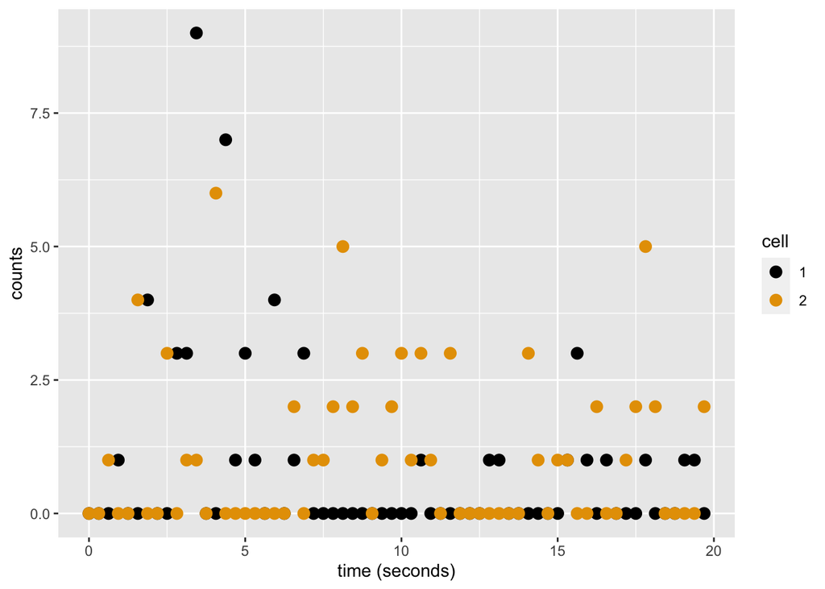

```r
counts <- model$compute_observations()
observations <- counts$observations
nobservations <- counts$nbins # same as time discretization

gridcells <- data.frame(time = counts$time[1:nobservations],
                        count = observations[, 1],
                        cell = factor(rep(1, nobservations)))
gridcells <- rbind(gridcells, data.frame(time = counts$time[1:nobservations],
                                         count = observations[, 2],
                                         cell = factor(rep(2, nobservations))))
ggplot(gridcells, aes(x = time, y = count, colour = cell)) + geom_point(size = 3) +
  xlab("time (seconds)") + ylab("counts") + scale_color_colorblind()
```

# Unbiased estimation

Below we specify all objects needed for our unbiased estimation procedure. We use the `independent_sum` estimator to obtain unbiased score approximations. Although unbiased estimators typically inflate the variance, this can be controlled using the time-averaging tuning parameters `k` and `m`.

```r
# settings
theta <- rep(1, model$theta_dimension) # fix a vector of parameters
discretization <- model$construct_successive_discretization(level = 13) # construct time-discretization objects
nparticles <- 2^8 # number of particles
resampling_threshold <- 0.5 # adaptive resampling threshold
coupled2_resampling <- coupled2_maximal_independent_residuals # Algorithm 3 of the article
coupled4_resampling <- coupled4_maximalchains_maximallevels_independent_residuals # Algorithm 5 of the article
initialization <- "dynamics" # choice to initialize CPF chains from time-discretized diffusion process
algorithm <- "CPF" # standard CPF algorithm

# distribution to truncate discretization level
minimum_level <- 11
maximum_level <- 15
level_distribution <- compute_level_distribution(model, minimum_level, maximum_level)
pmf.df <- data.frame(support = level_distribution$support, probability = level_distribution$mass_function)

# compute independent sum estimator of score function
score <- independent_sum(model, theta, observations, nparticles, resampling_threshold, coupled2_resampling, coupled4_resampling, initialization, algorithm, k = 50, m = 50, level_distribution)
```

```
## running minimum level
## meeting time: 2
## minimum level completed
## random level: 11
```

```r
score
```

```
## $random_level
## [1] 11
##
## $unbiasedestimator
##  [1] -11.7991824   1.4255795  -5.9401651  -1.2611273  16.1751331  -5.9189727
##  [7]  -5.9032344   4.3759507  -6.1485735  -0.3260622   7.3288139   0.8509439
##
## $cost
## [1] 26738688
##
## $elapsedtime
## elapsed
##  13.365
```

# References

Brown, Emery N. 2005. “The Theory of Point Processes for Neural Systems.” In *Methods and Models in Neurophysics*, edited by C. C. Chow, B. Gutkin, D. Hansel, C. Meunier, and J. Dalibard, 691–726. Elsevier.

Hafting, Torkel, Marianne Fyhn, Tora Bonnevie, May-Britt Moser, and Edvard I Moser. 2008. “Hippocampus-Independent Phase Precession in Entorhinal Grid Cells.” *Nature* 453 (7199): 1248–52.